# Logistic Regression

In this blog post, I will introduce the basics for understanding Logistic Regression that we learned in Lecture 6.  
Here is the list of the topics I will cover:

- Background
- Derivation
- Visualization
- Interpretation and Application

## Background for Logistic Regression

Previously we have learned *linear regression* that can map input X values into output Y. Here, both X and Y are continuous.  
Logistic regression is a kind of classification because the output value is not continuous anymore. The output becomes discrete that is either 0 or 1.  
The general idea of logistic regression is similar to linear regression that it performs some regression model to a $d*n$ dimension of input data X and output Y of dimension $n$. The difference is that logistic regression aims to get an output of Y which only belongs to 0 and 1.  
Therefore, our goal is to get a discrete output from a continuous input.

## Deriving Logistic Function

Since the difference between classification and regression is only about the output. We can do some transformations to the well-known linear regression and derive logistic regression from it.  
For example, imagine we have a data that includes X as any real number and Y as 0 and 1, as shown below.

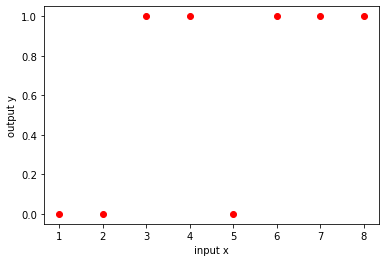

## Closer Look at Logistic Regression

- continuous
- non-linear
- bounded

To interpret the parameters of the logistic regression fucntion, we can think about a simplified model.  
For a simplified model with X being only 1 dimension, the $\beta_1$ can be interpreted as the slope of the regression, and $\beta_0$ is the position of the regression. This is just like how we interpreted the parameters of linear regression.  
Now, we understand the basics for interpreting the logistic regression function, the problem is: how are we going to use it?  
The examples we used above all have the output Y being 0 and 1, but it does not always have to be equal to 0 and 1. Since we know it is a kind of classification, the output can be any two discrete values, or even categorical values. What we do is just map the output into 2 different boxes.  
For example, we can run a data of people's score of depression. Here the X is the score of depression and Y is the whetehr the person is happy or not. We can run a logistic regression to achieve that. The regression helps us predicting whether a person with certain score of depression is happy or not.

[figure not shown]

Hope this blog post makes the concepts of Logistic Regression clear!